# Vokabular in Wahlprogrammen

Anina Klaus, Katja Konermann und Niklas Stepczynski

## Vorverarbeitung

Für die Verarbeitung der Wahlprogramme werden die Bibliotheken *readtext* und *quanteda* benötigt. Zudem wird die Biliothek *udpipe* benutzt, um das Korpus zu lemmatisieren. Die dazugehörige Funktion ist in der Datei *functions/lemmatize.R* gespeichert.

```r
library(quanteda)
library(readtext)
library(tidyverse)
library(udpipe)

source("functions/lemmatize.R")
```

Weil die Lemmatisierung einige Zeit braucht, ist die lemmatisierte Version des Korpus schon unter *RData/lemmatized_corpus.RData* abgespeichert. Zudem werden Stoppwörter geladen, die auf den *quanteda* eigenen Stoppwörtern aufbauen, aber noch einige zusätzliche enthalten.

```r
# Load lemmatized corpus
load("RData/lemmatized_corpus.RData")
# Load custom stopwords
load("RData/custom_stopwords.RData")
```

Die Stoppwörter werden dann aus den Wahlprogrammen herausgefiltert. Danach kann eine Document-Feature-Matrix erstellt werden.

```r
# Convert characters in year column to integers
docvars(programs, field="year") <- as.integer(docvars(programs, field="year"))

# Create tokens object for whole corpus, filter out stopwords.
program_toks <- tokens(programs,remove_punct = TRUE) %>% tokens_remove(custom_stops)

# Create dfm for corpus
program_dfm <- dfm(program_toks)
```

## Vergleich der häufigsten Terme zwischen den Parteien

Die folgenden 30 Terme treten insgesamt am häufigsten in den Wahlprogrammen zur Bundestagswahl auf. Eine Liste mit den 100 häufigsten Termen kann unter *data/bag_of_words.csv* abgerufen werden.

```
##          feature frequency rank docfreq group
## 1         müssen      6186    1       7   all
## 2         mensch      3099    2       7   all
## 3            gut      2905    3       7   all
## 4         sollen      2747    4       7   all
## 5    deutschland      2739    5       7   all
## 6           mehr      2739    5       7   all
## 7            neu      2519    7       7   all
## 8         sozial      2395    8       7   all
## 9           land      2146    9       7   all
## 10        setzen      1826   10       7   all
## 11      brauchen      1724   11       7   all
## 12    europäisch      1688   12       7   all
## 13       stärken      1644   13       7   all
## 14          kind      1518   14       7   all
```

[output cut: 16 more lines]

Um zu vergleichen, wie sich die relative Häufigkeit dieser Terme zwischen den Parteien unterscheidet, wird ein *data frame* erstellt, indem die relative Häufigkeit eines Terms für jede Partei gespeichert ist. Zur Berechnung der relativen Häufigkeit wird die Frequenz eines Terms durch die Summe aller Terme einer Partei dividiert. Die Frequenz wird also relativ zur Länge eines Wahlprogramms normalisiert.

```r
top.30 <- head(textstat_frequency(dfm(program_dfm, groups="party")), 30)
parties <- c("AfD", "CDU", "SPD", "PDS", "FDP", "DIELINKE", "B90dieGruene")

# Intialize data frame
terms.ranked <- data.frame(matrix(ncol = 3, nrow = 0))
colnames(terms.ranked) <- c("feature", "party", "relative")

# Iterate over parties and get relative frequency for each term.
for (i in 1:length(parties)){
  # Get programs for each party.
  stat.party <- dfm_subset(program_dfm, party == parties[i]) %>%
    textstat_frequency()
  # Get full term frequency for each party.
  sum.freq <- sum(stat.party$frequency)
  # Only keep top 30 terms.
  stat.party.filtered <- filter(stat.party, feature %in% top.30$feature)
  tmp.data <- data.frame(feature=stat.party.filtered$feature,
                         party=parties[i],
                         relativ=stat.party.filtered$frequency/sum.freq)
  terms.ranked <- rbind(terms.ranked, tmp.data)
}

head(terms.ranked, 20)
```

```
##        feature party     relativ
## 1       müssen   AfD 0.012223516
## 2  deutschland   AfD 0.011447419
## 3      deutsch   AfD 0.008925107
## 4       sollen   AfD 0.007081878
## 5         land   AfD 0.004365541
## 6         kind   AfD 0.004365541
## 7           eu   AfD 0.003201397
## 8   europäisch   AfD 0.003007373
## 9       dürfen   AfD 0.002910361
## 10        jahr   AfD 0.002910361
## 11      europa   AfD 0.002813349
## 12     stärken   AfD 0.002425301
## 13       recht   AfD 0.002328289
## 14        mehr   AfD 0.002231277
## 15      mensch   AfD 0.002231277
## 16      setzen   AfD 0.002134265
## 17      sozial   AfD 0.002134265
## 18    brauchen   AfD 0.001940241
## 19     fördern   AfD 0.001940241
## 20         neu   AfD 0.001940241
```

In einer Heatmap werden diese Häufigkeiten dann zwischen den Parteien verglichen. Niedrige relative Häufigkeiten sind dabei blau, hohe dagegen rot.

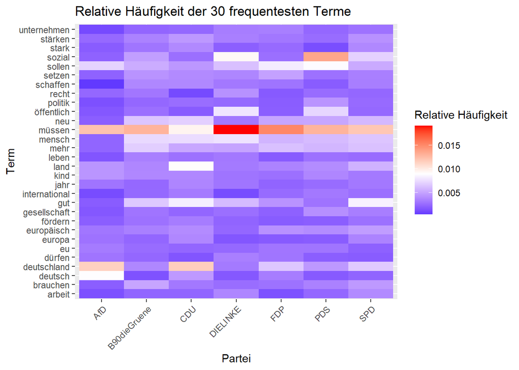

## TF-IDF Scores

Im Weiteren wird anhand der AfD erklärt, wie die TF-IDF Werte für eine Partei errechnet werden. In dem hier gezeigten Plot werden nur etwa 30 Terme, mit den höchsten TF-IDF Wert für jede Partei gezeigt. Für jede Partei ist eine Liste mit den 100 höchstbewerteten Termen in dem Verzeichnis *data* enthalten. Für die Darstellung der Terme werden zudem Selbstbezeichnungen wie *afd* herausgefiltert, weil diese oft einen sehr hohen Score haben, aber nicht sehr aussagekräftig sind.

```r
# Group dfm by party
party.dfm <- dfm(program_dfm, groups = "party")
# Create tfidf
tfidf <- dfm_tfidf(party.dfm)

# Get scores for AfD
tfidf.afd <- dfm_subset(tfidf, party == "AfD")

# Filter out self referential terms.
top.afd <- head(textstat_frequency(tfidf.afd, force =TRUE), 30) %>% filter(feature != "afd")
```

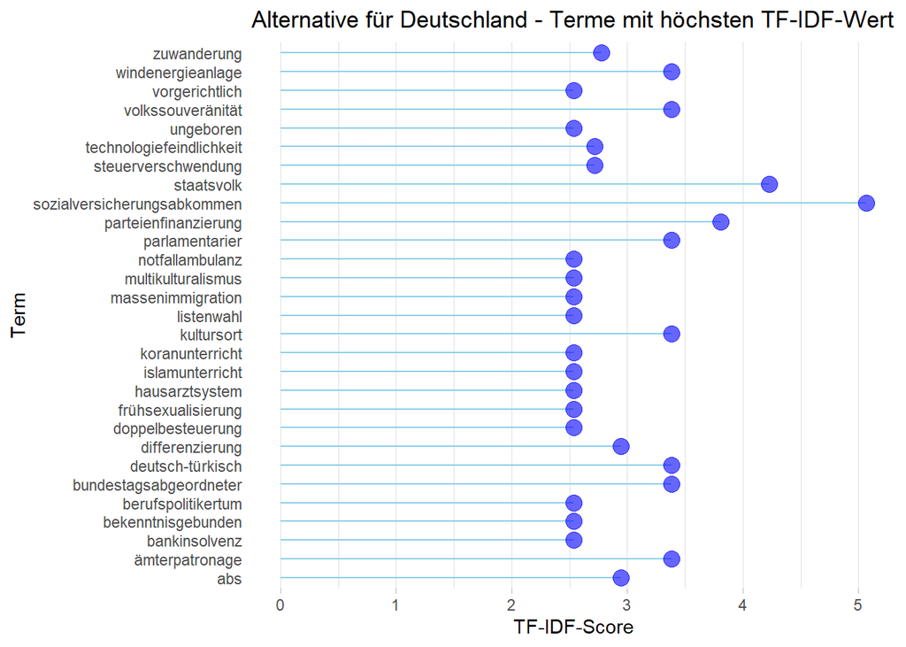

```r
ggplot(top.afd , aes(x=feature, y=frequency)) +
  geom_segment( aes(x=top.afd $feature, xend=top.afd $feature, y=0, yend=frequency), color="skyblue") +
  geom_point( color="blue", size=4, alpha=0.6) +
  theme_light() +
  coord_flip() +
  theme(
    panel.grid.major.y = element_blank(),
    panel.border = element_blank(),
    axis.ticks.y = element_blank()
  )+
  labs(x ="Term", y="TF-IDF-Score")+
  ggtitle("Alternative für Deutschland - Terme mit höchsten TF-IDF-Wert")
```

Die Plots für die übrigen Parteien wurden analog erstellt:

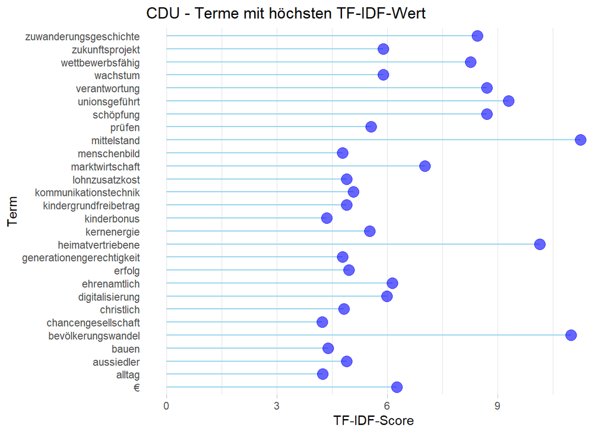

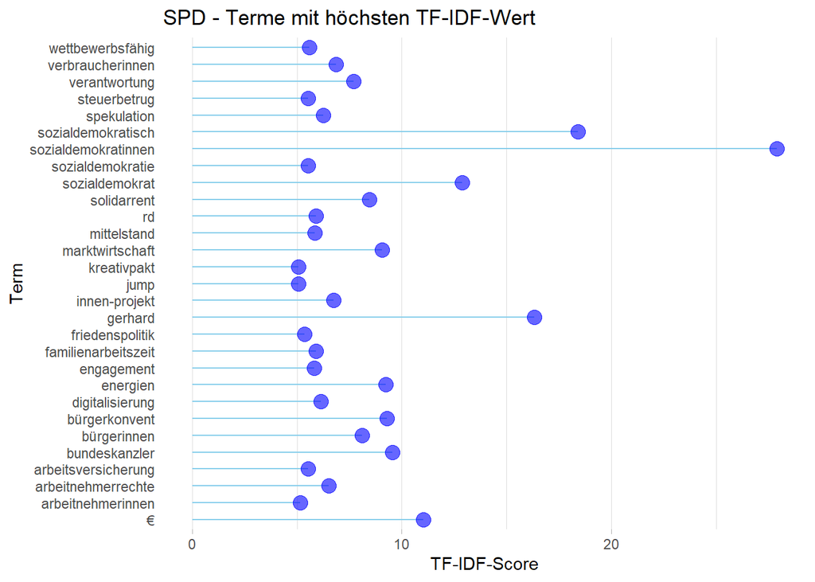

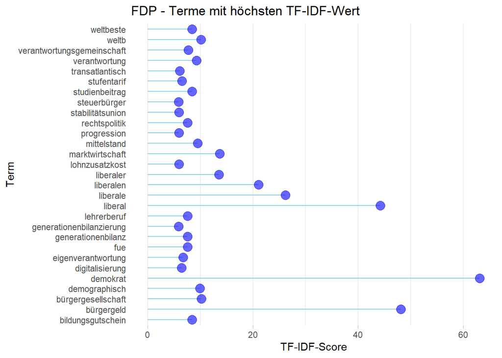

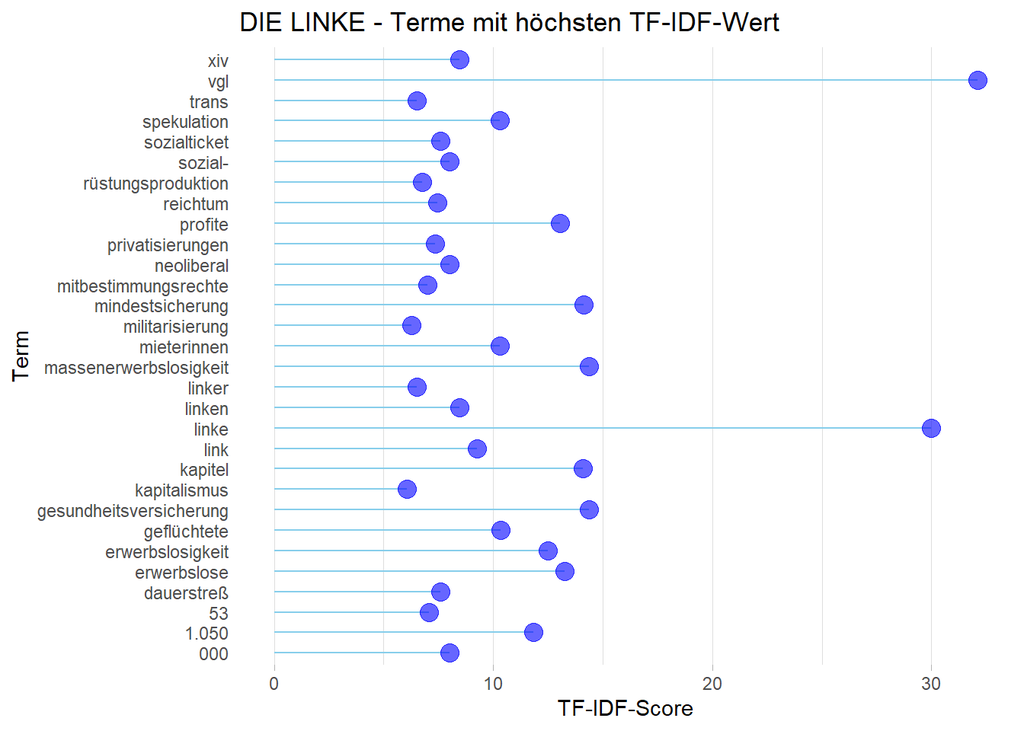

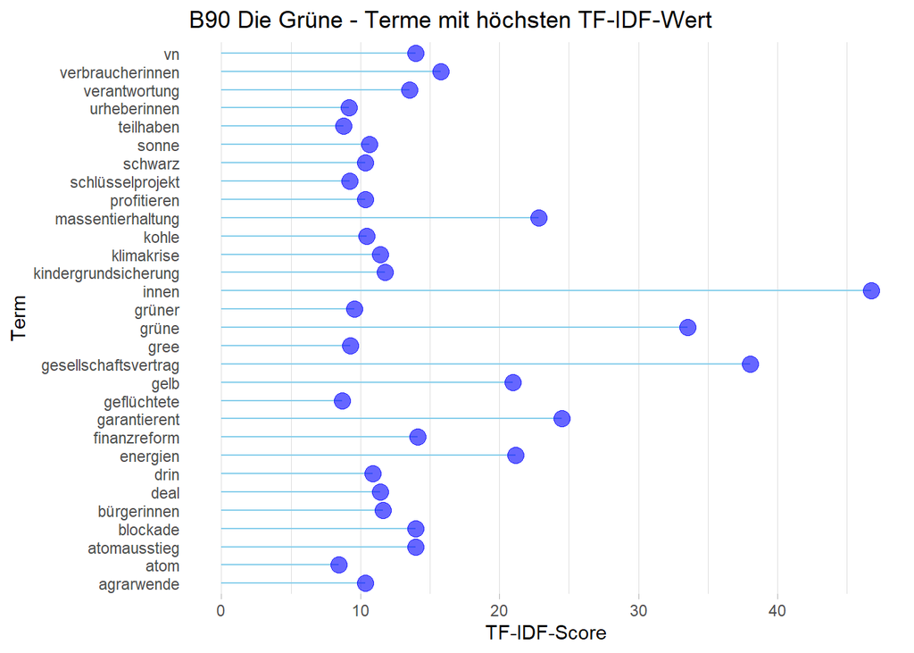

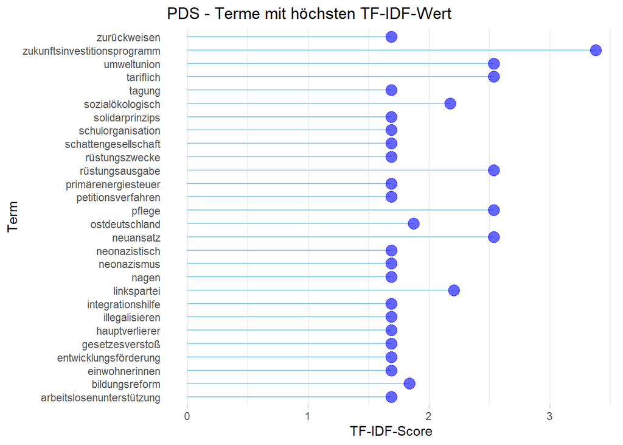